# Wednesday May 1, 2013 Stats 155 Class Notes

\( \newcommand{\ensuremath}[1]{#1} \newcommand{\pathway}[1]{\hbox{#1}} \newcommand{\causes}{\ensuremath{\Rightarrow}} \newcommand{\causedBy}{\ensuremath{\Leftarrow}} \newcommand{\correlatedWith}{\ensuremath{\nLeftrightarrow}} \)

## Survey processing

- Work through the write-up [here](http://rpubs.com/dtkaplan/5866).
- Have students work on the four tasks by uploading the template and saving it. [Template](https://raw.github.com/dtkaplan/Statistical-Modeling-A-Fresh-Approach/gh-pages/Activities/SurveyReport.Rmd)

## Causality

### Software for Simulation

You should do this even if you already have done so. There were some corrections made to the software.

```r
fetchData("simulate.r")
```

```
## Retrieving from http://www.mosaic-web.org/go/datasets/simulate.r
```

```
## [1] TRUE
```

### An example hypothetical causal network

If we want to study the direct link between class size and test scores, we need to block the backdoor pathways.

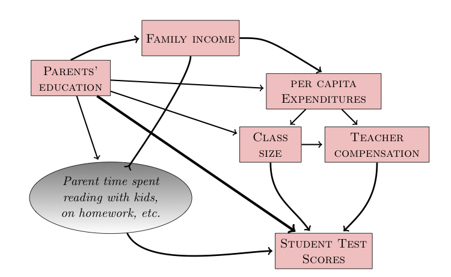

### Chains in Causation

Following the convention used throughout the book

- \( A \) is a response variable
- \( B \) is an explanatory variable
- \( C \) is a covariate. We'll also use \( D \), \( E \), etc. as covariates and \( U \) or \( ? \) as unobserved variables.

#### Three linear pathways:

- **Causal mediator**: \( A \causedBy C \causedBy B \). Simulation: `cnet.mediator`
- **Common cause**: \( A \causedBy C \causes B \). Simulation: `cnet.common.cause`
- **Witness**: \( C \) is caused by both \( A \) and \( B \): \( A \causes C \causedBy B \). Simulation: `cnet.witness`

#### A circular pathway

- A **recurrent network** (or, closed loop of causation): : \( A \causes B \causes C \causes A \) or the variations.

We won't deal with these. They raise questions about “when”.

#### Correlation

The notation \( A \correlatedWith B \) means that there is a non-causal connection between \( A \) and \( B \). This must be because there is some unobserved variable \( U \) producing the correlation, such as

1. \( A \causedBy U \causes B \)
2. \( A \causes U \causedBy B \)

Note that if either of the arrows went the other way, we'd simply have \( U \) being a causal mediator.

### The Rules for Observing or Blocking a Pathway

Remember, we want to study the **causal** relationship between \( A \) and \( B \) and are trying to decide whether to include the covariate \( C \).

- Causal mediator: Including \( C \) **blocks** the pathway, which is otherwise open.
- Common cause: Including \( C \) **blocks** the pathway, which is otherwise open.
- Witness: Including \( C \) **opens** the pathway, which is otherwise blocked.

### Confirming these rules

Run a simulation of \( A \) against \( B \). When the coefficient in a model is zero, the pathway between \( B \) and \( A \) has been blocked.

#### Mediator

```r
equations(cnet.mediator)
```

```
## B <== rnorm(nsamps)
## C <== B + rnorm(nsamps)
## A <== rnorm(nsamps) - C
```

```r
s = run.sim(cnet.mediator, 1000)
coef(summary(lm(A ~ B, data = s)))
```

```
##              Estimate Std. Error  t value  Pr(>|t|)
## (Intercept)  0.006554    0.04483   0.1462 8.838e-01
## B           -0.977772    0.04625 -21.1432 2.771e-82
```

The above model indicates that the pathway is open.

Including the covariate \( C \) blocks the pathway between \( B \) and \( A \).

```r
coef(summary(lm(A ~ B + C, data = s)))
```

```
##              Estimate Std. Error  t value   Pr(>|t|)
## (Intercept)  0.006143    0.03196   0.1922  8.476e-01
## B            0.009186    0.04577   0.2007  8.410e-01
## C           -0.994755    0.03200 -31.0884 6.776e-149
```

### Common Cause

```r
equations(cnet.common.cause)
```

```
## C <== rnorm(nsamps)
## B <== rnorm(nsamps)+C
## A <== rnorm(nsamps)-C
```

```r
s = run.sim(cnet.common.cause, 1000)
coef(summary(lm(A ~ B, data = s)))
```

```
##             Estimate Std. Error  t value  Pr(>|t|)
## (Intercept)  0.03654    0.03898   0.9373 3.488e-01
## B           -0.48613    0.02669 -18.2131 3.258e-64
```

The above model indicates that the pathway is open.

Including the covariate \( C \) blocks the pathway between \( B \) and \( A \).

```r
coef(summary(lm(A ~ B + C, data = s)))
```

```
##             Estimate Std. Error t value  Pr(>|t|)
## (Intercept)  0.04690    0.03161   1.483 1.383e-01
## B            0.03449    0.03144   1.097 2.730e-01
## C           -1.01498    0.04447 -22.826 4.148e-93
```

### Witness

```r
equations(cnet.witness)
```

```
## A <== rnorm(nsamps)
## B <== rnorm(nsamps)
## C <== rnorm(nsamps) - A + B
```

```r
s = run.sim(cnet.witness, 1000)
coef(summary(lm(A ~ B, data = s)))
```

```
##             Estimate Std. Error t value Pr(>|t|)
## (Intercept) -0.01741    0.03224 -0.5399   0.5894
## B           -0.01511    0.03251 -0.4646   0.6423
```

The above model indicates that the pathway is blocked.

Including the covariate \( C \) opens the pathway between \( B \) and \( A \).

```r
coef(summary(lm(A ~ B + C, data = s)))
```

```
##             Estimate Std. Error t value   Pr(>|t|)
## (Intercept) -0.03783    0.02216  -1.707  8.805e-02
## B            0.52827    0.02762  19.125  1.066e-69
## C           -0.51283    0.01534 -33.434 5.519e-165
```

### The Jock Network

Imagine that we wanted to study the relationship between athletic ability and SAT scores. The conventional wisdom is that athletes tend to have lower test scores. The `jock` network implements one hypothesis.

```r
s = run.sim(jock, 1000)
head(s)
```

```
##       IQ Athletic College Varsity
## 1  95.77    18.99      No      No
## 2  92.10    24.54      No      No
## 3  70.75    23.94      No      No
## 4 111.32    23.82     Yes     Yes
## 5 115.24    19.63     Yes      No
## 6 108.79    20.18     Yes      No
```

In practice, SAT and athletic ability data on an individual might be available via a college, so let's pull out just the cases that are in college:

```r
college <- subset(s, College == "Yes")
```

Look at the relationship between IQ and Athletic:

```r
coef(summary(lm(IQ ~ Athletic, data = college)))
```

```
##             Estimate Std. Error t value   Pr(>|t|)
## (Intercept)  152.194     4.3625  34.887 3.930e-108
## Athletic      -1.707     0.2009  -8.496  8.981e-16
```

There is a relationship!

Now look at the entire set of data:

```r
coef(summary(lm(IQ ~ Athletic, data = s)))
```

```
##             Estimate Std. Error t value   Pr(>|t|)
## (Intercept) 98.73122     3.3287 29.6609 3.845e-139
## Athletic     0.08128     0.1646  0.4939  6.215e-01
```

The relationship has disappeared. Why?

ACTIVITY: Look at the structure and equations of the `jock` network and explain.

### In-Class Activity

Here is the complete set of simple causal pathways among three variables.

- In each case, write down whether the pathway is a mediator, a common cause, or a witness.
- We've only studied the pathways with C in the middle. For the others, figure out whether including C as a covariate opens or blocks the pathway between A and B.
- Come up with a setting which assigns a meaning to A, B, and C. Example: B is taking nitroglycerin, C is dilation of the arteries, A is getting a headache.

The possibilities for who can be in the middle: \( A \) or \( B \) or \( C \)

#### \( C \) in the middle

- \( B \causedBy C \causes A \)
- \( B \causedBy C \causedBy A \)
- \( B \causes C \causedBy A \)
- \( B \causes C \causes A \)

#### \( A \) in the middle

- \( B \causedBy A \causes C \)
- \( B \causedBy A \causedBy C \)
- \( B \causes A \causedBy C \)
- \( B \causes A \causes C \)

#### \( B \) in the middle

- \( A \causedBy B \causes C \)
- \( A \causedBy B \causedBy C \)
- \( A \causes B \causedBy C \)
- \( A \causes B \causes C \)